# Science & adaptive management

## Science

- Science is a provisional belief system.
- Science differs from other belief systems in that scientific knowledge is under a constant process of revision.
- Existing knowledge can be revised, reinforced, or wholly rejected based on the demonstration of observable, reproducible, evidence.
- By this definition knowledge which cannot be updated can not be scientific.
- This is known as the *falsification principle*.

## Why is science important?

- It is a philosophical model which allows our knowledge to be updated
- Paradigms can be challenged
- Over time should result in a better understanding of systems
- & therefore more effective interventions
- *But it can’t tell us anything about the morality of the interventions*

## The Deming cycle

- Four steps: **Plan – Do – Check – Act**
- The Deming cycle is based on the scientific method in which:
  - **Plan – Do – Check** =

    **Hypothesis – Experiment – Evaluation**

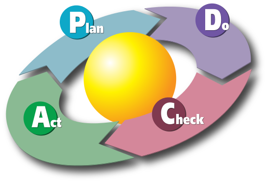

## Monitoring and evaluation

- **Check** phase: examine effectiveness of intervention
  - This is called:

    **Monitoring and Evaluation (M & E)**
- **Act** phase: separates out academics from implementers

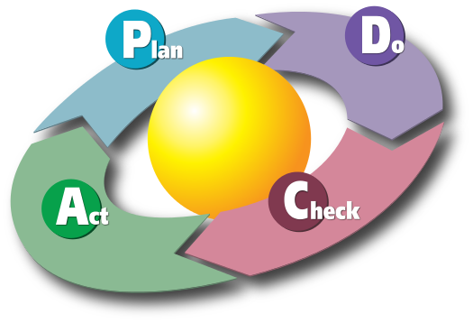

## Adaptive management cycles

Cycles outline how to operationalise a project

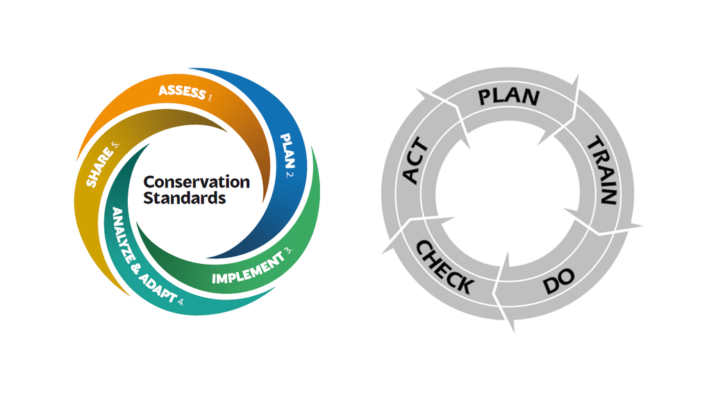

## Projects vs programmes

### Project

- A project can be thought of as something temporary: a set of activities which has to deliver a certain outcome within a set deadline.

### Programme

- A programme operates on a longer time frame than a project and may run for decades.
- A programme exists to achieve the longer-term goals of the organisation.

## Project delivery versus research projects

- Academic settings the approach normally revolves around research projects not project delivery
- Research projects apply the scientific method in order to test a set of hypotheses,
  - so long as the research results in a conclusion it is successful.
- In project delivery success is dependent a specific outcome occurring.
- There is a contractual obligation for certain outcomes to be delivered.

## Summary

- Science is a provisional knowledge system
- Adaptive management is based on the science method
- Monitoring and evaluation occurs in the **Check** phase
- **Act** phase differentiates academics from implementers

## Next up…

*Evidence and decision making*